# HPI Bayesian Course

# Set options

# Terms and abbreviations

## Week 1

- *RV*: random variable
- *Bernoulli* distribution: univariate binomial
- *PMF*: probability mass function (binomial)
- *CMF*: cumulative mass function (binomial)
- *standard normal distribution*: mean = 0, sd = 1
- *f* = *PDF*: probability density function (continuous)
- *CDF*: cumulative density function (continuous)
- *k*: number of successes
- *n*: number of trials
- $\theta$: the probability of success
- *AUC*: area under the curve
- *univariate*: one variable
- *bivariate*: 2 variables
- *multivariate*: 2+ variables
- *variance* = sd^2

## Week 2

- *P(A|B)*: probability of A given B
- *P(A,B)*: probability of A and B
- *f* = *PDF*: probability density function (continuous)
  - so *f($theta$|y)*: PDF of theta given a certain value of y

# 1 Week 1: Introduction

## 1.1 Discrete random variables

- random variables are functions that map one set to the set of real numbers
  - associates to each outcome to a particular real number

There’s a set of events that *can* happen, like tossing a coin. A random variable maps each of these possible events to a real number. In tossing a coin until you get a heads, a random variable would be the number of tosses until you get a ‘success’ (heads). In principle it could be an infinite set, bcause you could in theory toss the coin an infinite number of times without ever getting a heads (though this is extremely improbable).

Alternatively, the random variable can be a finite set if we are interested in looking whether *one* toss results in a head or a tails.

PMF: probability mass function, PDF: probability density function

- PMF = for discrete distributions
- PDF: for continuous
- CDF: cumulative distribution function; gives a mapping from a particular numerical value to a probability; means the probability of getting that number or something less than it.

Simulate tossing a coin 10 times with probability of heads = 0.5, with a Bernoulli random variable.

```r
# simulate tossing a coin 10 times
extraDistr::rbern(n = 10, prob = .5)
```

```
##  [1] 1 0 1 0 0 1 0 1 1 0
```

What’s the probablity of getting a tails or a heads? The d-family of functions:

```r
extraDistr::dbern(0,prob=.5)
```

```
## [1] 0.5
```

```r
extraDistr::dbern(1,prob=.5)
```

```
## [1] 0.5
```

Cumulative probability distribution function: the p-family of functions

```r
# probability distribution function

## for whichever case we coded as 0
extraDistr::pbern(0,.5)
```

```
## [1] 0.5
```

```r
## for whichever case we coded as 1
extraDistr::pbern(1,.5)
```

```
## [1] 1
```

## 1.2 Discrete random variables: the binomial

When we toss a coin only once, this is a Bernoulli random variable. If we toss the coin more than once, this is a *binomial*. Both Bernoulli and Binomial have a PMF associated with them.

```r
# generate random binomial data
rbinom(n = 10, size = 1, prob = .5)
```

```
##  [1] 1 1 1 0 1 0 0 1 0 0
```

```r
# compute probabilites of a particular outcome
probs <- round(dbinom(0:10, size = 10, prob = .5),3); probs
```

```
##  [1] 0.001 0.010 0.044 0.117 0.205 0.246 0.205 0.117 0.044 0.010 0.001
```

```r
x <- 0:10
rbind(x,probs)
```

```
##        [,1] [,2]  [,3]  [,4]  [,5]  [,6]  [,7]  [,8]  [,9] [,10]  [,11]
## x     0.000 1.00 2.000 3.000 4.000 5.000 6.000 7.000 8.000  9.00 10.000
## probs 0.001 0.01 0.044 0.117 0.205 0.246 0.205 0.117 0.044  0.01  0.001
```

```r
# compute cumulative probabilities of all possible outcomes
pbinom(0:10, size=10, prob = .5)
```

```
##  [1] 0.0009765625 0.0107421875 0.0546875000 0.1718750000 0.3769531250
##  [6] 0.6230468750 0.8281250000 0.9453125000 0.9892578125 0.9990234375
## [11] 1.0000000000
```

Compute quantiles using the inverse of the CDF: what is the quantile q such that the probability of X is greater than x?

```r
# generate distribution (0:10 outcomes or less, for 10 repetitions, with probability .5)
probs <- pbinom(0:10,size = 10, prob = .5)


# compute the inverse CDF; qbinom takes as its input a probability of an outcome and outputs the inverse
qbinom(probs, size = 10, prob=.5)
```

```
##  [1]  0  1  2  3  4  5  6  7  8  9 10
```

### 1.2.1 My summary notes

d-p-q-r family of functions

| RV | Function(arguments) | Outcome |
| --- | --- | --- |
| Bernoulli | `rbern(n,prob)` | generate random data |
|  | `dbern(x,prob)` | PMF: *probability* of outcome x |
|  | `pbern(q,prob)` | CMF: cumulative PMF of <=q |
| Binomial | `rbinom(n, size, prob)` | generate random data with n = of successes |
|  | `dbinom(q,size,prob)` | PMF: *probability* of outcome x |
|  | `pbinom(q,size,prob)` | CMF: cumulative PMF of <=q |
|  | `qbinom(p,prob,size)` | inverse CMF: cumulative PMF of >=x |
| normal | `rnorm(n,mean,sd)` | generate random data |
|  | `dnorm(x,mean,sd)` | PDF: *density* of outcome x |
|  | `pnorm(q,mean,sd)` | CDF: cumulative PDF of <=q |
|  | `pnorm(q,mean,sd,` `lower.tail=F)` | inverse CDF: cumulative PDF of >=q |
|  | `qnorm(p,prob,size)` | Compute quantiles corresponding to probabilities |

## 1.3 Continuous random variables (PDFs)

- in discrete RV cases, we compute the probability of a *particular* outcome
- in continous RV cases, probability is defined by the *area under the curve* (AUC)
- we use the cumulative distribution function associated with a normal distribution to compute this AUC; i.e., the probability of observing a value between x1 and x2

## 1.4 Continous RVs: the normal distribution

- the standard normal distribution:
  - Normal(mean = 0, sd = 1)
  - Prob(-1 < X < 1) = 68%
  - Prob(-1.96 < X < 1.96) = 95%
  - Prob(-3 < X <3) = 99.7%
- for any other normal distribution (with varying mean and sd):
  - Prob(-1*sd < X < 1*sd ) = 68%
  - Prob(-1.96*sd < X < 1.96*sd ) = 95%
  - Prob(-3*sd < X <3*sd ) = 99.7%
- the continuous vales on the x-axis (here, +/- 1,2,3) are the **quantiles**

`rnorm(n,mean,sd)`: Generate random data using

```r
rnorm(n=5,
      mean = 0,
      sd = 1)
```

```
## [1] -1.7423762  1.5093688  0.5218357  1.3696954  0.3483563
```

`pnorm(q,mean,sd)`: Compute probabilities using CDF

```r
pnorm(q = 2,
      mean = 0,
      sd = 1)
```

```
## [1] 0.9772499
```

`pnorm(q,mean,sd,lower.tail=F)`: Compute inverse probabilities using CDF

```r
pnorm(q = 2,
      lower.tail=F,
      mean = 0,
      sd = 1) # don't look the left (equal to or less than q), but the right (equal or greater than q)
```

```
## [1] 0.02275013
```

`qnorm(p,mean,sd))`: Compute quantiles corresponding to probabilities using the inverse of the CDF

```r
qnorm(p = 0.9772499,
      mean = 0,
      sd = 1)
```

```
## [1] 2.000001
```

`dnorm(x,mean,sd)`: Compute the probability *density* for a quantile value

- not the probability of a particular outcome
- rather the **density** of that particular value, i.e., the y-axis value

```r
dnorm(x = 2,
      mean = 0,
      sd = 1)
```

```
## [1] 0.05399097
```

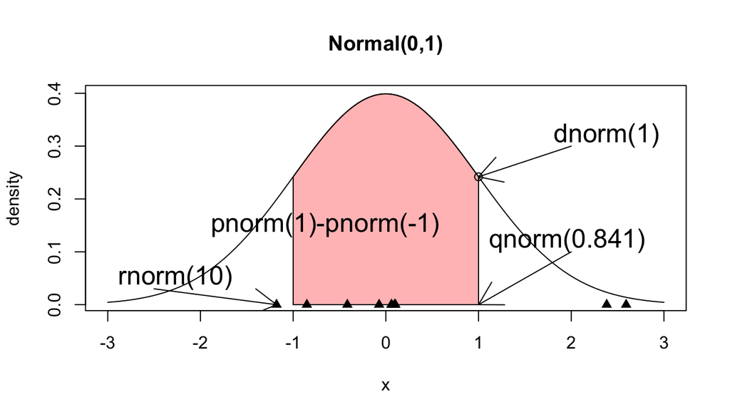

```r
curve(dnorm(x,0,1), xlim=c(-3,3), main="Normal(0,1)",
      ylab="density")
from.z <- -1
to.z <- 1
S.x  <- c(from.z, seq(from.z, to.z, 0.01), to.z)
S.y  <- c(0, dnorm(seq(from.z, to.z, 0.01)), 0)
polygon(S.x,S.y, col=rgb(1, 0, 0,0.3))
text(-2,0.15,pos=4,cex=1.5,paste("pnorm(1)-pnorm(-1)"))
arrows(x1=2,y1=0.3,x0=1,y0=dnorm(1),code = 1)
text(1.7,0.32,pos=4,cex=1.5,paste("dnorm(1)"))
points(1,dnorm(1))
#points(1,0)
arrows(x1=2,y1=0.1,x0=1,y0=0,code = 1)
text(1,0.12,pos=4,cex=1.5,paste("qnorm(0.841)"))
x<-rnorm(10)
points(x=x,y=rep(0,10),pch=17)
text(-3,0.05,pos=4,cex=1.5,paste("rnorm(10)"))
arrows(x1=-2.5,y1=0.03,x0=min(x),y0=0,code = 1)
```

## 1.5 Maximum Likelihood estimates

*Spoiler:* it’s pretty much the mean/mode/median of normally distributed data (where the three would be the same value); gives us the most likely value that the parameter $\theta$ has *given the data*

- the ‘expectation’ (discrete case)
- if you were to do an experiment with a larger and larger sample size, you’d get closer to the expected value (e.g., value of .5 successes in repeated coin tosses)
- we can estimate $\theta$ ($\theta$-hat), but we’ll never know the true value of $\theta$

From my book notes from SMLP 2022:

> In real exerimental situations we never know the true value of $\theta$ (probability of an outcome), but it can be derived from the data: *$\theta$ hat = k/n*, where *k* = number of observed successess, *n* = number of trials, and *$\theta$ hat* = observed proportion of successes. *$\theta$ hat* = *maximum likelihood estimate* of the true but unknown parameter *$\theta$*. Basically, the **mean** of the binomial distribution. The **variance** can also be estimated by computing *(n($\theta$))(1 - $\theta$)*. These estimates can be be used for statistical inference.

From my class notes from SMLP 2022:

> - common misunderstanding of the **maximum likelihood estimate (MLE)**: it doesn’t represent the true value of $\theta$, because it’s the MLE (best guess) for the *data you have*
> - but the MLE will be closer to the true value of $\theta$ as sample size increases
> - e.g., the PMF (binomial) contains three terms:
> - *k*: number of successes
> - *n*: total number of trials
> - *$\theta$*: probability of success (can have values between 0 and 1)
> - the PMF is a function of these parameters, based on the data (given our data we know the values of *k* and *n* so they are fixed quantities and no longer random), so $\theta$ can be treated as a variable
- the **likelihood function** is the PMF (or PDF) as a function of the parameters, rather than a function of the data
- the MLE from a particular *sample* of data doesn’t necessarily give us an accurate estimate of the true value of $\theta$ (because it’s just a sample, of course)
  - larger sample sizes get MLEs that more accurately represent the true value of $\theta$ (again, duh because of the point made above regarding the expectation)

## 1.6 Bivariate and multivariate distributions (Discrete case)

- *univariate* distributions: only one variab le
- *bivariate* or *multivariable* distributions: multiple variables
- *Bernoulli* distribution: univariate binomial data
- *joint probability mass function* (PMF): the joint distribution of multivariate binomial data
- joint probability density function would be for continuous data
- each RV has its own PMF that can be computed separately
- you can also compute the **conditional distribution**, i.e., the probability of x given y (x|y) or of y given x (x|y)
  - the conditional probability of *x|y* is going to be the joint distribution of *x,y* divided by the marginal distribution of a particular value of y

## 1.7 Bivariate and multivariate distributions (Continuous case)

- only going to discuss bivariate distributions here cause they’re easier to conceptualize
- we’d take into account the mean and sd of each variable, as well as the correlation between the two
- in a bivariate case, the diagonals (from top left downward) of the VarCorr matrix will contain the *variances* of either RV
  - the off-diagonals (from bottom left upward) contain the *covariance* from the two RVs
- *covariance* = the correlation of the two RVs multiplied by each of their SDs: *Cov(X,Y)* = $\rho$XY$\sigma$X$\sigma$Y
- this allows us to describe how these 2 RVs are jointly distributed
- in the joint PDF: AUC sums to 1 but will be a 3D cone, rather than a 2D curve as in the univariate case
- we can also compute the marginal distributions, just as in the bivariate discrete case
- simulating data:

```r
# generate simulated bivariate data

## define a VarCorr matrix, where rho = .6, variance
Sigma <- matrix(c(
  5^2, 5 * 10 * .6, # variance = sd^2, covariance=sd*sd*rho  (.6)
  .5 * 10 * .6, 10^2 # covariance=sd*sd*rho  (.6) * correlation (.6), variance = sd^2
  ),
  byrow = F, ncol = 2
  )

## generate data
u <- as.data.frame(MASS::mvrnorm(n = 100, mu = c(0,0), Sigma = Sigma))
head(u, n=3)
```

|  | V1 | V2 |
| --- | --- | --- |
| 1 | -1.473300 | 3.071680 |
| 2 | -3.838910 | -14.850276 |
| 3 | -1.861792 | -7.713124 |

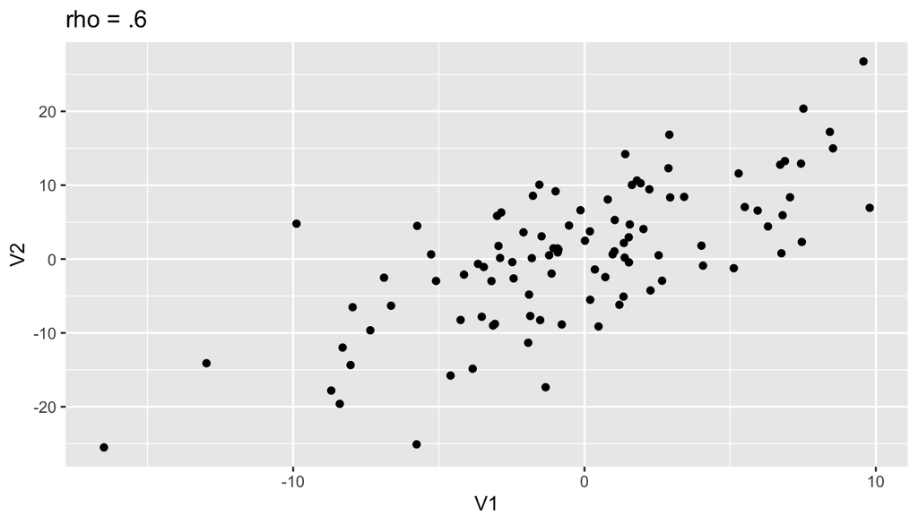

```r
## plot data
# plot(u)

ggplot2::ggplot(u, aes(x = V1, y = V2)) +
    labs(title = "rho = .6") +
    geom_point()
```

# 2 Week 2: Bayesian data analysis

## 2.1 Bayes’ Rule

- suppose you have 2 discrete events (A: the streets are wet, B: it is raining)
  - the probability of A given B is the joint probability of A and B divided by the marginal probability of that particular value of B (where P(B) > 0)
    - this conditional probability rules leads ot Bayes’ rule
- *P(A|B) = P(A,B)/P(B) where P(B) > 0*
- *P(A,B) = P(B,A)*
- *P(B,A) = P(B|A)P(A) = P(A|B)P(B) = P(A,B)*
- rearranging the terms, we get Bayes’ rule:
  - *P(B|A) = P(A|B)P(B) / P(A)*
- but in real world we’re usually working with multivariate (and continuous) data
  - we can re-write Bayes’ rule in terms of density function (curly *f*)
  - *f()* refers to a PDF, not the probability of a single event
  - $theta$ is now a random variable: *f($theta$)
  - *f($theta$|y)*: PDF of \$theta$ given our observed data (y)
- an example with a discrete RV: if *n* = 10 trials and *k* = 7 successes, and if we suppose there are three possible values of $theta$: .1,.5, and .9 and each has the probability of 1/3, the likelihood function would be:

```r
sum(dbinom(x = 7, # k successes
           size=10, # n trials
           prob=c(0.1,0.5,0.9) # theta values
           )
    )/3 # divided by 3 because each theta has p = 1/3
```

```
## [1] 0.05819729
```

## 2.2 Bayes’ rule in action: Binomial-beta conjugate case

```r
# a discrete example
dbinom(x = 46, # k successes
       size = 100, # n trials
       prob = .5 # theta
       )
```

```
## [1] 0.0579584
```

- the beta distribution is defined in terms of *a* and *b*
  - B(a,b) refers to a particular beta distribution with some values a and b
  - in R, a and b are written as `shape1` and `shape2`

```r
dbeta(x, #
      shape1, # parameter a
      shape2 # parameter b
)
```

- beta distribution’s a and b can be interpreted as our beliefs about prior successes and failurs
  - once we choose a and b, we can plot the beta PDF

```r
# will spit out the *density* (y-axis value) at a certain point along the curve
dbeta(x = .5,
      shape1=1,
      shape2=1
      )
```

```
## [1] 1
```

```r
dbeta(x = .5,
      shape1=3,
      shape2=3
      )
```

```
## [1] 1.875
```

```r
dbeta(x = .5,
      shape1=6,
      shape2=6
      )
```

```
## [1] 2.707031
```

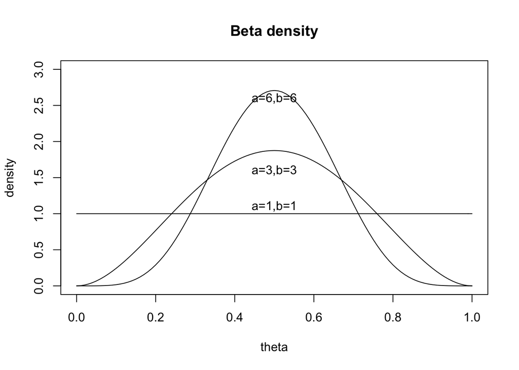

```r
plot(function(x)
  dbeta(x,shape1=1,shape2=1), 0,1,
      main = "Beta density",
  ylab="density",xlab="theta",ylim=c(0,3))

text(.5,1.1,"a=1,b=1")

plot(function(x)
  dbeta(x,shape1=3,shape2=3),0,1,add=TRUE)
text(.5,1.6,"a=3,b=3")


plot(function(x)
  dbeta(x,shape1=6,shape2=6),0,1,add=TRUE)
text(.5,2.6,"a=6,b=6")
```

```r
## observed values
x <- 46
n <- 100

## prior specification
a <- 210
b <- 21

binom_lh <- function(theta) {
  dbinom(x=x,
         size=n,
         prob=theta)
}

## normalising constant
K <- 1/integrate(f = binom_lh, lower=0,upper=1)$value

binom_scaled_lh <- function(theta)K*binom_lh(theta)
```

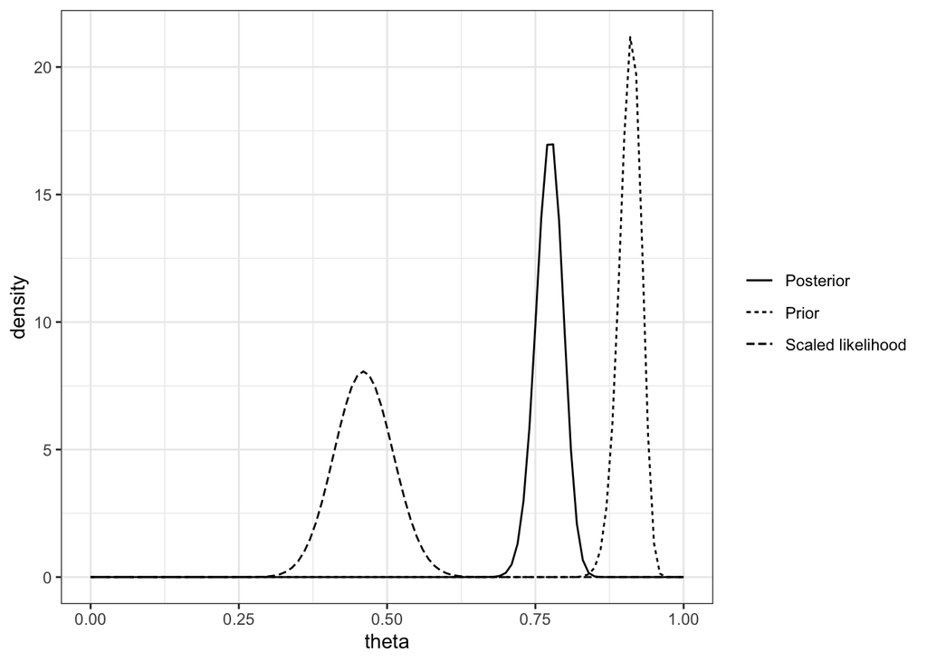

```r
# Plot normalized prior, posterior, and observed data
## Likelihood
p_beta <- ggplot(data = tibble(theta = c(0, 1)), aes(theta)) +
  stat_function(
    fun = dbeta,
    args = list(shape1 = a,
                shape2 = b),
    aes(linetype = "Prior")
  ) +
  ylab("density") +
  stat_function(
    fun = dbeta,
    args = list(shape1 = x + a,
                shape2 = n - x + b),
    aes(linetype = "Posterior")
  ) +
  stat_function(
    fun = binom_scaled_lh,
    aes(linetype = "Scaled likelihood")
  ) +
  theme_bw() +
  theme(legend.title = element_blank())
p_beta
```

- here we see that the posterior is a compromise between the prior and the likelihood
- the more precise the prior is, the more the posterior will shift to the prior

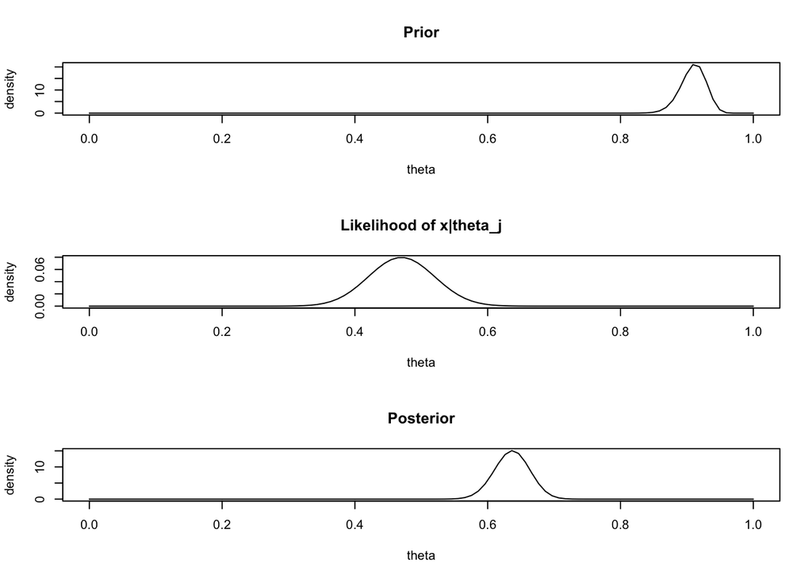

```r
thetas<-seq(0,1,length=100)
op<-par(mfrow=c(3,1))

## prior
plot(thetas,dbeta(thetas,shape1=a,shape2=b),type="l",
     main="Prior",xlab="theta",ylab="density")

## lik
probs<-rep(NA,100)

for(i in 1:100){
probs[i]<-dbinom(47,100,thetas[i])
}

plot(thetas,probs,main="Likelihood of x|theta_j",type="l",xlab="theta",ylab="density")

## post
x<-seq(0,1,length=100)

a.star<- x + a
b.star<- n - x + b

plot(x,dbeta(x,shape1=a.star,shape2=b.star),type="l",
     main="Posterior",xlab="theta",ylab="density")
```

## 2.3 Bayes’ rule in action: Poisson-Gamma conjugate case

- imagine a dataset with the number of regressions as a DV (discrete continuous)
- a and b are called `shape` and `rate``

```r
# simulate data
round(rgamma(
  n=10,
  shape=3,
  rate=1),
  2)
```

```
##  [1] 3.92 2.20 5.53 0.92 0.86 3.60 0.39 4.29 5.00 4.26
```

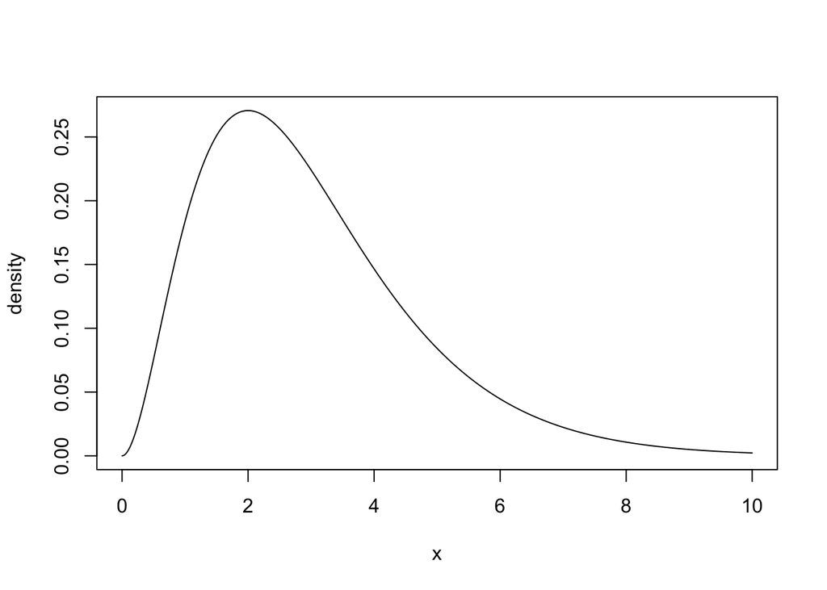

```r
# plot
x<-seq(0,10,by=0.01)
plot(x,dgamma(x,shape=3,rate=1),type="l",
     ylab="density")
```

- to set our priors, we have to decide what the values of a and b will be
- suppose we know the mean and variance from prior research is 3 and 1.5
  - in a gamma PDF, the mean is a over b and the variance is a over b-squared

$\frac{a}{b}$ = 3 $\frac{a}{b^{2}}$ = 1.5 = $\frac{\frac{a}{b}}{b}$ = $\frac{3}{b}$ = 1.5 then $\frac{3}{1.5}$ = $b$ = 2

## 2.4 Bayes’ rule in action: Poisson-Gamma conjugate case cont’d

- we assume a Poisson likelihood for the data (number of regressive eye movements)
  - we know from expert knowledge that the mean rate of regressive eye movements is 3, with a variance of 1.5
  - recall that we know in a gamma distribution that the mean is a/b and the variance is a/(b^2). We can now solve for a and b
    - a/b = 3, a/(b^2) = 1.5
    - a/(b^2) = (a/b)/b = 3/b = 1.5, and so 3/1.5 = b

## 2.5 The posterior mean

- we’re now going to look at the Poisson-gamma case
- if we have a Gamma prior with a Poisson likelihood
- recall: the Poisson distribution is for discrete cases and has one parameter: the rate (e.g., number of regressions)
  - we first need to define a PDF for $\lambda$, which is the unknown rate; the $gamma(a,b)$ distribution (for continuous data) is a good choice

Take aways - when data are sparse, the prior will dominate in determining the posterior mean - when a lot of data are available, the MLE will dominate in determining the posterior mean - give sparse data, informative priors based on expert knowledge, existing data, or meta-analysis will play an important role

# 3 Week 3: Computational Bayes

## 3.1 Computational Bayes I

Quick review:

- Bayes’ rule when A and B are **discrete events**:

$$P(A\mid B) = \frac{P(B\mid A) P(A)}{P(B)}
\tag{2.1}$$

- Bayes’ rule with distributions ($\theta$ can be a vector of parameters):

$$p(\theta\mid y) = \frac{p(y\mid \theta) p(\theta)}{p(y)}
\tag{2.1}$$

- $\theta$ can be a vector of parameters in multivariate cases; this makes it difficult to calculate a posterior distribution (joint distribution) on paper
- the posterior distribution is of central interest to us
- we’re really interested in the posterior distribution *up to proportionatlity* (without the )
- imagine we know what the posterior distribution is
  - you can now find out the creidble interval

```r
# 95% credible interval
qgamma(
  c(.025,.975),
  shape=20, # a
  rate=7) # b
```

```
## [1] 1.745217 4.238693
```

- but with a large number of samples from this distirbution, we can use these samples to draw essentially the same conclusions:

```r
# generate posterior samples from a gamma distribution: 4000 obvs
lambda_posterior <- rgamma(
  40000, # n
  shape = 20, # a
  rate = 7 # b
)

# now compute CrI using samples from the posterior distribution
round(quantile(lambda_posterior, probs = c(.025,.975)),2)
```

```
##  2.5% 97.5%
##  1.75  4.24
```

- this is *obtaining samples for the posterior distributions*
- Bayesian analyses is really *uncertainty quantification*
- these samples from the posterior distribution are what we can get through MCMC sampling
- our main goal will always be to obtain this posterior distribution:

$$p(\theta\mid{y})$$

- in the beta-binomial and Poisson-gamma cases, we could derive the posterior analystically
- in more complex Bayesian models, we need to use some sampling method (MCMC sampling) to obtain **posterior samples** of the parameters

An example:

- suppose we have data from a single subject, whose only task is to repeatedly press the spacebar without paying attention to any stimuli
- the data are response times in ms per trial
- we would like to know how long it takes to press a key for this subject

```r
library(bcogsci)
data("df_spacebar")
head(df_spacebar,n=2)
```

| rt | trial |
| --- | --- |
| 141 | 1 |
| 138 | 2 |

- good to always first look at your data, so let’s look at a density plot:

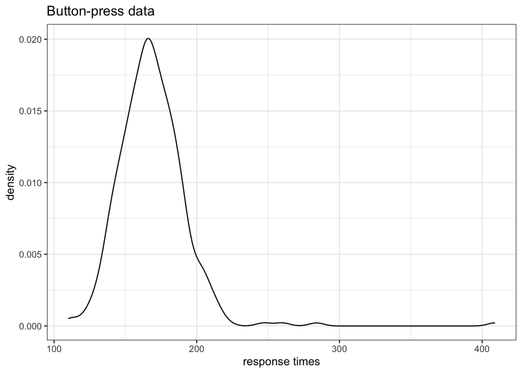

```r
ggplot(df_spacebar, aes(rt)) +
  geom_density() +
  xlab("response times") +
  ggtitle("Button-press data")+theme_bw()
```

## 3.2 Computational Bayes II

- assume this statistical model (n: the n-th row in the data frame):

$$rt_n \sim \mathit{Normal}(\mu, \sigma)$$

- this model can also be written for a linear model, where rt_{n} = some intercept ($\mu$) + noise ($\varepsilon$), where the residuals of the noise have a normal distribution ($iid$ means ‘independent and identically distributed’)

$$rt_n = \mu + \varepsilon \hbox{, where } \varepsilon_n
\stackrel{iid}{\sim} \mathit{Normal}(0,\sigma)$$

- so it is assumed that the residuals are normally distributed, and that there is some unknown variable $\mu$ and some unknown parameter $\sigma$, that represents the variability around $\mu$, and that the noise ($\varepsilon$) is Gaussian (normally distributed)
- in a Frequentist model, we’d run:

```r
m <- lm(rt~1, df_spacebar)
coef(m) # intercept, i.e., the mean value of the data
```

```
## (Intercept)
##    168.6399
```

```r
sigma(m) # residual error
```

```
## [1] 24.9118
```

```r
# these are the same as mean and sd of RT
mean(df_spacebar$rt)
```

```
## [1] 168.6399
```

```r
sd(df_spacebar$rt)
```

```
## [1] 24.9118
```

- the intercept and residual error are just the maximum likelihood estimates from the data, i.e., the mean and sd
- the linear model is pretty much giving you 2 MLE, one for the intercept and for the residual error
- **Frequentist**: $\mu$ and $\sigma$ are *fixed*, unknown point values in frequentist models
- in the **Bayesian world**, $\mu$ and $\sigma$ are *random variables* and need prior distributions specified for them
  - i.e., we don’t *just* have the MLE
  - we define priors on the $\mu$ and $\sigma$ priors; these are no longer unknown points out there in nature, there is some prior knowledge being brought in
- let’s start with (unrealistic) flat/uniform priors:

$$\mu \sim Uniform(0,60000)\\
\sigma \sim Uniform(0,2000)$$

- uniform priors mean that all the values between a and b are equally likely (hence the ‘flat’ label; it’s not a curve but a flat line)
- you can choose whatever prior makes sense to you
- the function `brm` has the same formula syntax as `lm`

```r
fit_press <- brm(
  # model specification
  rt ~ 1,
  data = df_spacebar,
  # the likelihood assumed:
  family = gaussian(),  # likelihood has normal distr.
  #   prior specifications:
  prior = c(
    prior(
      uniform(0, 60000), # uniform/flat prior
      class = Intercept, # mean
      lb = 0,  # lb/ub: technical details, truncate the sampling
      ub = 60000
    ),
    prior(uniform(0, 2000), # uniform/flat prior
          class = sigma, # sd
          lb = 0,
          ub = 2000)
  ),
  # sampling specifications
  # Technical stuff
  # backend = "cmdstanr",
  chains = 4, # this is the default
  iter = 2000, # this is the default
  warmup = 1000 # this is the default
  )
```

[output not shown]

- *chains*: the number of *independent runs* for sampling (by default 4)
- *iter*: the number of *iterations* that the *sampler* makes to sample from the posterior distribution of each paramter (by default 2000)
- *warmup*: the number of *iterations* from the *start of sampling* that are eventually discarded (by default half of ‘iter’) (in WinBUGS/JAGS this is called burn-in)
- **relevant reading**: sampling and convergence in a nutshell in Ch. 3

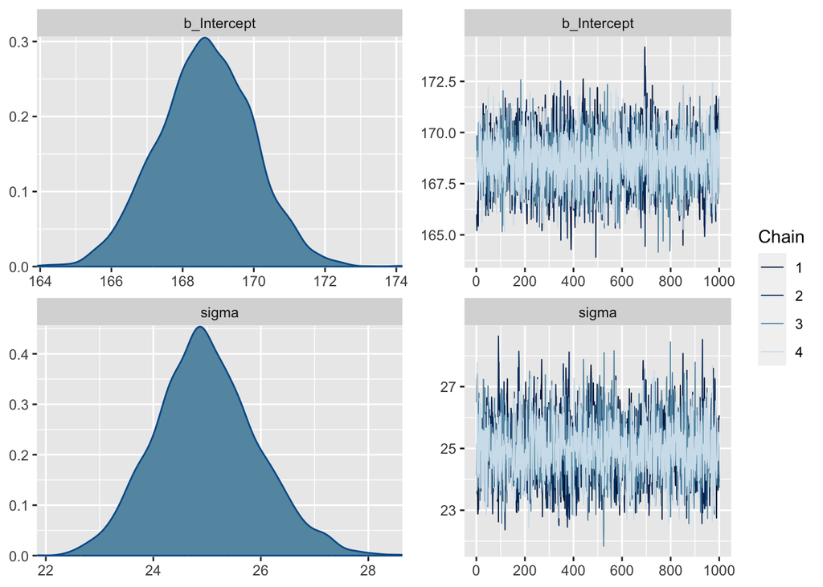

```r
plot(fit_press)
```

- we get a visual graphic of how the sample was searching in the posterior distribution
- the caterpillar plot shows us the chains sitting on top of each other; a **fat hairy caterpillar** means the chains are all consistantly sampling from the same distribution, this is *good*
- if we don’t see a afat hairy caterpillar, this indicates a **convergence failure** (if the chains are not really aligning)
- also try using `shinystan`:

```r
library(shinystan)
launch_shinystan(fit_press)
```

```r
# extract the posterior distributions as vectors
as_draws_df(fit_press) %>%
  head(3)
```

| b_Intercept | sigma | lprior | lp__ | .chain | .iteration | .draw |
| --- | --- | --- | --- | --- | --- | --- |
| 168.7527 | 24.11824 | -18.603 | -1683.139 | 1 | 1 | 1 |
| 168.7907 | 25.14754 | -18.603 | -1682.788 | 1 | 2 | 2 |
| 169.1915 | 24.37999 | -18.603 | -1683.009 | 1 | 3 | 3 |

```r
# compute mean
as_draws_df(fit_press)$b_Intercept %>%
  mean()
```

```
## [1] 168.6372
```

```r
# compute 95% CrI for the mean
as_draws_df(fit_press)$b_Intercept %>%
  quantile(c(.025,.975))
```

```
##     2.5%    97.5%
## 166.0262 171.1923
```

```r
# compute sd
as_draws_df(fit_press)$sigma %>%
  mean()
```

```
## [1] 24.99241
```

```r
# computer 95% CrI for sigma
as_draws_df(fit_press)$sigma %>%
  quantile(c(.025,.975))
```

```
##     2.5%    97.5%
## 23.22645 27.00463
```

## 3.3 Computational Bayes III

- we’ll now talk about
  - prior predictive distributions
  - posterior predictive distributions

### Prior predictive distributions

The model specification, again:

- we can generate the **prior predictive distirubiton** given the model above ($\theta =< \mu,\sigma>$) by integrating out the theta parameters
- to do this, do the following many times:
1. Take one sample from each of the priors

```r
mu <- runif(1, min=0, max=60000)
sigma <- runif(1, 0, 2000)
```

2. Plug those samples into the probability density/mass function used as the lieklihood in the model to generate a data set $y_{pred1}, ..., y_{predn}$

```r
y_pred_1 <- rnorm(n=5, mu, sigma)
y_pred_1
```

```
## [1] 39843.65 39766.19 39666.18 39829.95 39686.40
```

- each sample is an imaginary or portential data set
- in the textbook, there’s code for generating prior predictive data using R
- what are our options regarding the priors?
- in the book, there are some classifications of priors ($Normal+$ indicates normal distribution truncated at 0, i.e., no negative values):
  - *flat*, uniformative priors: e.g., $\mu \sim Uniform(-10^{20}, 10^{20})$
    - very wide range for mean, and very large sd
    - but for reaction/reading times, this isn’t reasonable
  - *regularising* priors: e.g., $\mu \sim Normal_+(0,1000)$
    - here we use 0-truncated normal distribution (positive values only)
    - but the only information we’ve given is really that the mean must be positive
  - *principled* priors: e.g., $\mu \sim Normal(250,100)$
    - principled because it centeres the mean at 250, which is reasonable, but is quite liberal in the sd (=100)
  - *informative* priors: e.g., $\mu \sim Normal+(200,20)$
    - if doing hypothesis testing with Bayes’ factor, using informative priors is extremely important
    - this is a much tighter prior; these are generally used in real research when possible (given enough prior knowledge)

## 3.4 Computation Bayes IV

- now we’ll see what happens when we specify different priors in our model
- there’s no standard terminology for types of priors, but we use:
  - flat/uninformative
  - regularising
  - principled
  - informative
- we’re going to see how using these different types of prior specifications alter the posterior distribution
  - we’ll run a **sensitivity analysis** to see how affected by the prior our posterior
  - if you ahve lots of data, the posterior should be affected mainly by the likelihood estimate
- let’s refit our model with *flat, uninformative priors*:

$$\begin{align}
\mu &\sim Uniform(-10^6,10^6)\\
\sigma &\sim Uniform(0,10^6)\\
rt_{n} &\sim Normal(\mu, \sigma)
\end{align}$$

```r
# new model with uninformative priors
fit_press_unif <- brm(
  # model specification
  rt ~ 1,
  data = df_spacebar,
  # the likelihood assumed:
  family = gaussian(),  # likelihood has normal distr.
  #   prior specifications:
  prior = c(
    prior(
      uniform(-10^6, 10^6), # uniform/flat prior
      class = Intercept, # mean
          lb = -10^6,
          ub = 10^6
    ),
    prior(uniform(0, 10^6), # uniform/flat prior
          class = sigma, # sd
          lb = 0,
          ub = 10^6
          )
  ),
  # sampling specifications
  # Technical stuff
  # backend = "cmdstanr",
  chains = 4, # this is the default
  iter = 2000, # this is the default
  warmup = 1000 # this is the default
  )
```

[output not shown]

```r
# earlier model
as_draws_df(fit_press)$b_Intercept %>%
  quantile(c(0.025, 0.975))
```

```
##     2.5%    97.5%
## 166.0262 171.1923
```

```r
# new flat/uninformative model
as_draws_df(fit_press_unif)$b_Intercept %>%
  quantile(c(0.025, 0.975))
```

```
##     2.5%    97.5%
## 166.0792 171.2173
```

- and a very *informative prior*:

$$\mu \sim Normal(400,10)
\sigma \sim Normal_{+}(100,10)
rt_{n} \sim Normal(\mu, \sigma)$$

```r
# new model with uninformative priors
fit_press_inf <- brm(
  # model specification
  rt ~ 1,
  data = df_spacebar,
  # the likelihood assumed:
  family = gaussian(),  # likelihood has normal distr.
  #   prior specifications:
  prior = c(
    prior(
      normal(400, 10),
      class = Intercept),
    # brms knows that SDs need to be bounded
    # to exclude values below zero:
    prior(normal(100,10), # informative
          class = sigma # sd
          )
  ),
  # sampling specifications
  # Technical stuff
  # backend = "cmdstanr",
  chains = 4, # this is the default
  iter = 2000, # this is the default
  warmup = 1000 # this is the default
  )
```

[output not shown]

```r
# new flat/uninformative model
as_draws_df(fit_press_inf)$b_Intercept %>%
  quantile(c(0.025, 0.975))
```

```
##     2.5%    97.5%
## 170.1966 175.7443
```

- these posteriors are shifted a bit to the right (bigger) because the prior was very tight, but not by much
- and with a *principled prior*:

$$\mu \sim Normal(200,100)
\sigma \sim Normal_{+}(50,50)
rt_{n} \sim Normal(\mu, \sigma)$$

```r
fit_press_prin <- brm(rt ~ 1,
  data = df_spacebar,
  family = gaussian(),
  prior = c(
    prior(normal(200, 100), class = Intercept),
    # brms knows that SDs need to be bounded
    # to exclude values below zero:
    prior(normal(50, 50), class = sigma)
  ),
  # sampling specifications
  # Technical stuff
  # backend = "cmdstanr",
  chains = 4, # this is the default
  iter = 2000, # this is the default
  warmup = 1000 # this is the default
)
```

[output not shown]

```r
# new principled model
as_draws_df(fit_press_prin)$b_Intercept %>%
  quantile(c(0.025, 0.975))
```

```
##     2.5%    97.5%
## 166.1515 171.2139
```

- between the informative and principled priors, we see the more uncertain (principled) prior has posterior more similar to the posteriors in the uninformative model
  - this means that with a principled prior the model is still relying mostly on the likelihood distribution
  - this is what we want
- this was our sensitivity analysis
  - it showed that the posterior is not overly affected by the choice of prior (good!)
  - the posterior is a compromise between the prior and the likelihood
  - informative prior with *sparse data* $\rightarrow$ the prior will dominate in determining the posterior
  - a lot of data $\rightarrow$ the likelihood will dominate in determining the posterior
- it is good practice to carry out a sensitivity analysis (with more experience you’ll have a better handle of when it’s absolutely necessary)

## 3.5 Computational Bayes V

- it’s best to use the log normal with right-skewed data

### Using the log-normal likelihood

- if $y$ is log-normally distributed, then log($y$) is normally distributed
  - the log-normal distribution is also defined using the parameters location ($\mu$) and scale ($\sigma$)
- $\mu$ and $\sigma$ are now on the log millisecond scale

$$\begin{align}
log(y) &\sim Normal(\mu,\sigma)\\
y &\sim LogNormal(\mu,\sigma)
\end{align}$$

- generating simulated data from a log normal

```r
mu <- 6
sigma <- 0.5
N <- 500000

# generate N random smaples from log-normal distribution
sl <- rlnorm(N, mu, sigma)
```

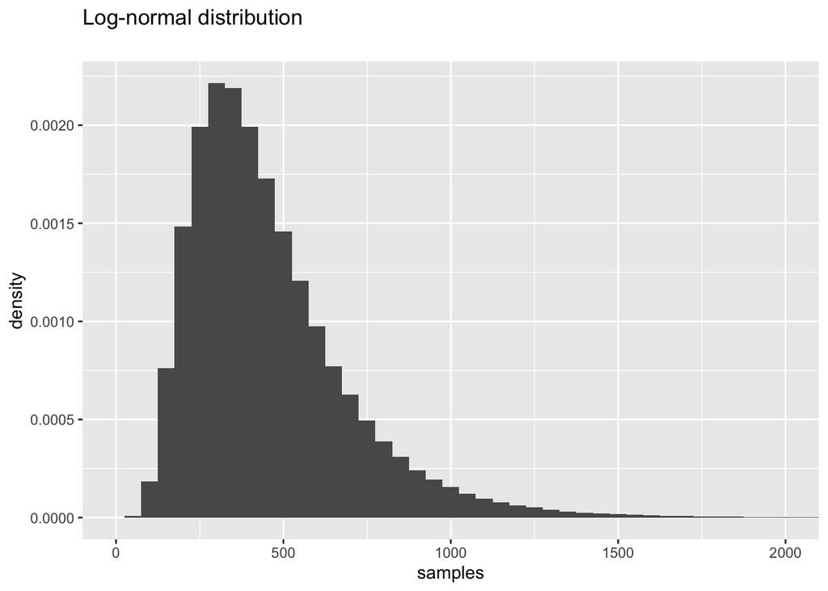

```r
ggplot(tibble(samples = sl), aes(samples)) +
  geom_histogram(aes(y = ..density..), binwidth = 50) +
  ggtitle("Log-normal distribution\n") +
  coord_cartesian(xlim = c(0, 2000))
```

- we need to change our likelihood functions and the scale of our priors!

$$rt_n \sim LogNormal(\mu,\sigma)$$

- uniform priors:

$$\begin{align}
\mu &\sim Uniform(0,11)\\
\sigma &\sim Uniform(0,1)
\end{align}$$
- generate prior predictive distributions:

```r
normal_predictive_distribution <-
  function(mu_samples, sigma_samples, N_obs) {
    # empty data frame with headers:
    df_pred <- tibble(
      trialn = numeric(0),
      rt_pred = numeric(0),
      iter = numeric(0)
    )
    # i iterates from 1 to the length of mu_samples,
    # which we assume is identical to
    # the length of the sigma_samples:
    for (i in seq_along(mu_samples)) {
      mu <- mu_samples[i]
      sigma <- sigma_samples[i]
      df_pred <- bind_rows(
        df_pred,
        tibble(
          trialn = seq_len(N_obs), # 1, 2,... N_obs
          rt_pred = rnorm(N_obs, mu, sigma),
          iter = i
        )
      )
    }
    df_pred
  }
```

```r
N_samples <- 1000
N_obs <- nrow(df_spacebar)
mu_samples <- runif(N_samples, 0, 11)
sigma_samples <- runif(N_samples, 0, 1)
prior_pred_ln <- normal_predictive_distribution(
  mu_samples = mu_samples,
  sigma_samples = sigma_samples,
  N_obs = N_obs
) %>%
  mutate(rt_pred = exp(rt_pred))
```

- now let’s take a look at some distributions of the simulated data sets

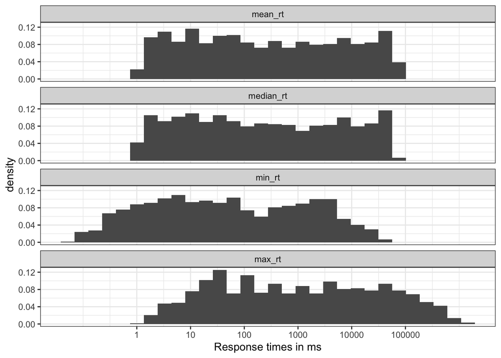

```r
prior_pred_ln %>%
  group_by(iter) %>%
  summarize(
    min_rt = min(rt_pred),
    max_rt = max(rt_pred),
    mean_rt = mean(rt_pred),
    median_rt = median(rt_pred)
  ) %>%
  pivot_longer(cols = ends_with("rt"), names_to = "stat", values_to = "rt") %>%
  mutate(stat = factor(stat, levels = c("mean_rt", "median_rt", "min_rt", "max_rt"))) %>%
  ggplot(aes(rt)) +
  scale_x_continuous("Response times in ms",
    trans = "log", breaks = c(0.001, 1, 10, 100, 1000, 10000, 100000)
  ) +
  geom_histogram(aes(y = ..density..)) +
  ylab("density") +
  facet_wrap(~stat, ncol = 1)+theme_bw()
```

- these are very broad ranges, because our prior specifications were so broad

## 3.6 Computational Bayes VI

- we saw a model with ridiculous priors
  - we know they’re ridiculous because of our prior knowledge about reaction times
  - more informative priors:

$$\begin{align}
\mu &\sim Normal(6,1.5)\\
\sigma &\sim Normal_+(0,1)
\end{align}$$
- and update our model + `brms` knows sd is truncated at 0 so we don’t have to specify `lb` and `ub` here; if you were writing directly in Stan code you’d have to specify it yourself

```r
df_spacebar_ref <- df_spacebar %>%
  mutate(rt = rep(1, n()))
fit_prior_press_ln <- brm(rt ~ 1,
  data = df_spacebar_ref,
  family = lognormal(), # log instead of gaussian
  prior = c(
    prior(normal(6, 1.5), class = Intercept), # on the log scale
    prior(normal(0, 1), class = sigma)
  ),
  sample_prior = "only", # produce prior samples
  control = list(adapt_delta = .9) # this was added for convergence reasons
)
```

[output not shown]

- to look at distribution of means of repeated samples based on priors

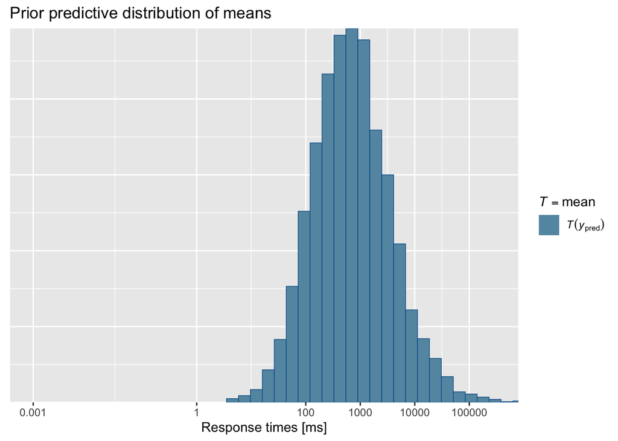

```r
pp_check(fit_prior_press_ln, type = "stat", stat = "mean",
         prefix = "ppd") +
  coord_cartesian(xlim = c(0.001, 300000)) +
  scale_x_continuous("Response times [ms]",
    trans = "log",
    breaks = c(0.001, 1, 100, 1000, 10000, 100000),
    labels = c(
      "0.001", "1", "100", "1000", "10000",
      "100000"
    )
  ) +
  ggtitle("Prior predictive distribution of means")
```

- we see the maximum values are a bit too large, but these are a huge improvement over those that we saw for the uniform priors in the last video

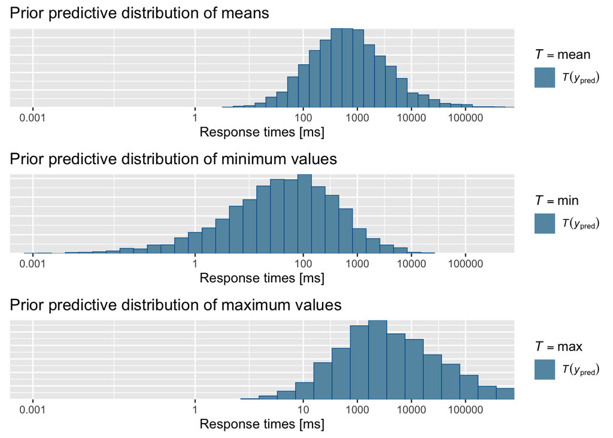

```r
p1 <- pp_check(fit_prior_press_ln, type = "stat", stat = "mean", prefix = "ppd") +
  coord_cartesian(xlim = c(0.001, 300000)) +
  scale_x_continuous("Response times [ms]",
    trans = "log",
    breaks = c(0.001, 1, 100, 1000, 10000, 100000),
    labels = c(
      "0.001", "1", "100", "1000", "10000",
      "100000"
    )
  ) +
  ggtitle("Prior predictive distribution of means")
p2 <- pp_check(fit_prior_press_ln, type = "stat", stat = "min", prefix = "ppd") +
  coord_cartesian(xlim = c(0.001, 300000)) +
  scale_x_continuous("Response times [ms]",
    trans = "log",
    breaks = c(0.001, 1, 100, 1000, 10000, 100000),
    labels = c(
      "0.001", "1", "100", "1000", "10000",
      "100000"
    )
  ) +
  ggtitle("Prior predictive distribution of minimum values")
p3 <- pp_check(fit_prior_press_ln, type = "stat", stat = "max", prefix = "ppd") +
  coord_cartesian(xlim = c(0.001, 300000)) +
  scale_x_continuous("Response times [ms]",
    trans = "log",
    breaks = c(0.001, 1, 100, 1000, 10000, 100000),
    labels = c(
      "0.001", "1", "10", "1000", "10000",
      "100000"
    )
  ) +
  ggtitle("Prior predictive distribution of maximum values")
cowplot::plot_grid(p1, p2, p3, nrow = 3, ncol =1)
```

- now fit the model to the data with a log normal likelihood

```r
fit_press_ln <- brm(rt ~ 1,
  data = df_spacebar,
  family = lognormal(),
  prior = c(
    prior(normal(6, 1.5), class = Intercept),
    prior(normal(0, 1), class = sigma)
  )
)
```

[output not shown]

```r
fit_press_ln
```

```
##  Family: lognormal
##   Links: mu = identity; sigma = identity
## Formula: rt ~ 1
##    Data: df_spacebar (Number of observations: 361)
##   Draws: 4 chains, each with iter = 2000; warmup = 1000; thin = 1;
##          total post-warmup draws = 4000
##
## Population-Level Effects:
##           Estimate Est.Error l-95% CI u-95% CI Rhat Bulk_ESS Tail_ESS
## Intercept     5.12      0.01     5.10     5.13 1.00     3730     2727
##
## Family Specific Parameters:
##       Estimate Est.Error l-95% CI u-95% CI Rhat Bulk_ESS Tail_ESS
## sigma     0.13      0.01     0.13     0.14 1.00     3162     2523
##
## Draws were sampled using sampling(NUTS). For each parameter, Bulk_ESS
## and Tail_ESS are effective sample size measures, and Rhat is the potential
## scale reduction factor on split chains (at convergence, Rhat = 1).
```

## 3.7 Computational Bayes

- now we’ll evaluate the log-normal model with these relatively informative priors
- back-transforming to ms:

```r
estimate_ms <- exp(as_draws_df(fit_press_ln)$b_Intercept)

round(c(mean = mean(estimate_ms),
  sd = sd(estimate_ms),
  quantile(estimate_ms,
           probs = c(.025,.975))),
  1)
```

```
##  mean    sd  2.5% 97.5%
## 167.1   1.2 164.7 169.5
```

- these credible intervals are conditioned on the data we happened to get, they don’t reflect any *true* mean necessarily
- we can also do a posterior predictive check:

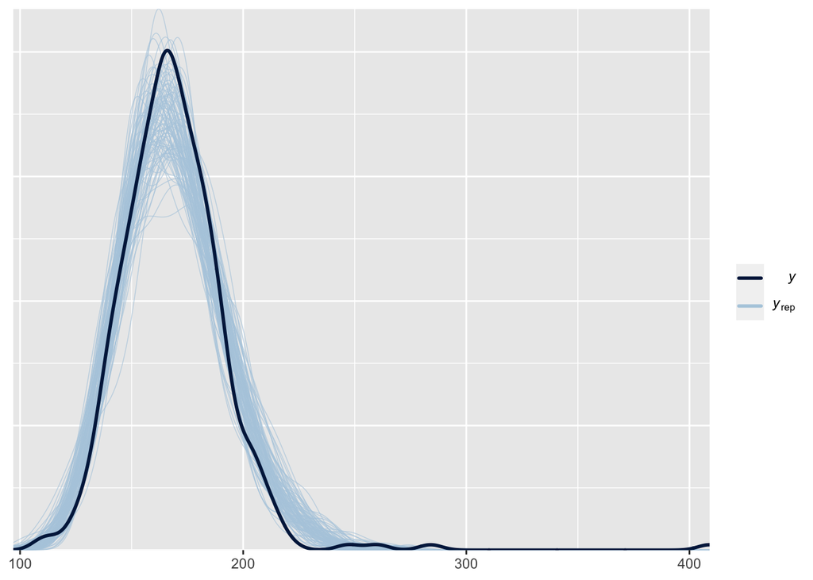

```r
pp_check(fit_press_ln, ndraws = 100)
```

- question: are the posterior predicted data now more similar to the observed data, compared to the case where we had a Normal likelihood?

```r
fit_press_norm <- brm(rt ~ 1,
  data = df_spacebar,
  family = gaussian(),
  prior = c(
    prior(uniform(0, 60000), class = Intercept, lb = 0,
          ub = 60000),
    prior(uniform(0, 2000), class = sigma, lb = 0,
          ub = 2000)
  ),
  chains = 4,
  iter = 2000,
  warmup = 1000
)
```

[output not shown]

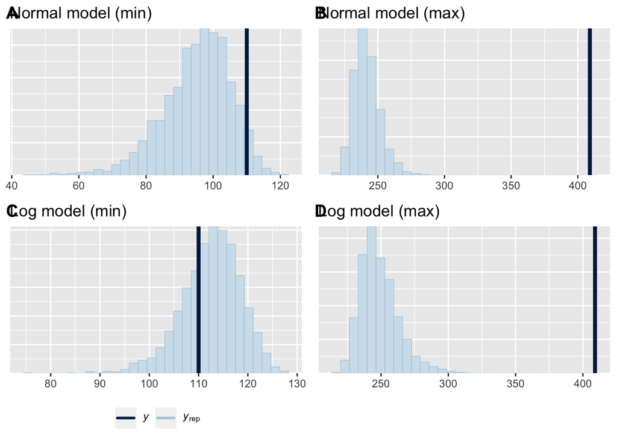

```r
ggpubr::ggarrange(
  pp_check(fit_press_norm,
         type = "stat", stat = "min") +
  ggtitle("Normal model (min)")+
  theme(legend.position = "none"),
pp_check(fit_press_norm,
         type = "stat", stat = "max") +
  ggtitle("Normal model (max)")+
  theme(legend.position = "none"),
pp_check(fit_press_ln,
         type = "stat", stat = "min") +
  ggtitle("Log model (min)")+
  theme(legend.position = "none"),
pp_check(fit_press_ln,
         type = "stat", stat = "max") +
  ggtitle("Log model (max)") +
  theme(legend.position = "none"),
cowplot::get_legend(pp_check(fit_press_norm) + theme(legend.position = "bottom")),
nrow = 3, ncol = 2,
heights = c(.45,.45,.1),
labels = c("A","B","C","D")
)
```

- here we see the normal model is producing values too small in the minimum values (more values lower than the actual minimum value), while the log model is doing a better job (A vs. C)
- for both normal and log models, the maximum reaction time is underestimated (B vs. D)

## 3.8 Summary

- we saw 2 simple examples of a liner model, with two differet likelihoods (normal and log normal)
- one key skill we learned was to examine and interpret the piror predictive distribution
- another key skill: interpreting the posterior predictive distribution
- these two distributions tell us how well themodel represents the realiy, both before and after observing the particular data we have
- Next:
  - addint a predictor: $y = \alpha + \beta \times x + \epsilon$
  - logistic regression
  - first steps in modeling repeated measures (dependent) data with hierarchical models: $y = \alpha + u_0 + \beta \times x + \epsilon$

# 4 Week 3: Regression models

## 4.1 Example: Multiple object tracking

- participant has to track between 0:5 objects on the screen, when there are several distractor objects on the screen as well
- examining attentional load, and its effect on **pupil size**
- our model:

$$p\_size_n \sim Normal(\alpha + c_load_n \cdot \beta, \sigma)$$

- $\beta$ = slope (determined by cognitive load)
- $\alpha$ = intercept, which will be the average effect of pupil size
- every data point is assumed to be independent (in frequentist terms: iid)

```r
data("df_pupil_pilot")
df_pupil_pilot$p_size %>% summary()
```

```
##    Min. 1st Qu.  Median    Mean 3rd Qu.    Max.
##   851.5   856.0   862.0   860.8   866.5   868.0
```

- this suggests we can use the following *regularizing* prior for $\alpha$

$$\alpha \sim Normal(1000,500)$$

- we are expressing with these priors that our plausible values for the Intercept will be (95% CrI)

```r
round(
  qnorm(c(.025,.975),
        mean = 1000,
        sd = 500),
  2)
```

```
## [1]   20.02 1979.98
```

- for $\sigma$, we use an uninformative prior

$$\sigma \sim Normal_+(0,1000)$$

```r
round(extraDistr::qtnorm(
  c(.025, .975),
  mean = 0,
  sd = 1000,
  a = 0 # truncate at 0
),
1)
```

```
## [1]   31.3 2241.4
```

- $\beta$ is ‘most important’ (effect of attentional load on pupil size)

$$\beta \sim Normal(0,100)$$

- not truncated, meaning we are agnostic in terms of whether the effect will be positive or negative

```r
round(
  qnorm(c(.025,.975),
      mean = 0, sd = 100),
  1)
```

```
## [1] -196  196
```

- these are what we’re saying we think the plausible values of $\beta$ will be
- let’s now work with the ‘real’ data, and centre the predictor
  - do this by subtracting the mean from each value
  - negative centered values represent values lower than the mean
- we see this data is repeated measure, because we have multiple data points from each participant for each load (2 times load = 0, for example)

```r
data("df_pupil")
df_pupil <- df_pupil %>%
  mutate(c_load = load - mean(load)); head(df_pupil,7)
```

| subj | trial | load | p_size | c_load |
| --- | --- | --- | --- | --- |
| 701 | 1 | 2 | 1021.4086 | -0.4390244 |
| 701 | 2 | 1 | 951.4349 | -1.4390244 |
| 701 | 3 | 5 | 1063.9569 | 2.5609756 |
| 701 | 4 | 4 | 913.4871 | 1.5609756 |
| 701 | 5 | 0 | 602.6868 | -2.4390244 |
| 701 | 6 | 3 | 826.2199 | 0.5609756 |
| 701 | 7 | 0 | 463.8021 | -2.4390244 |

- fit the model

```r
# only sigma is truncated at 0 in our priors, and it is also truncated at 0 by default in stan
# therefore, we don't need to set any ub/lb
fit_pupil <- brm(p_size ~ c_load,
                 data = df_pupil,
                 family = gaussian(),
                 prior = c(
                   prior(normal(1000,500), class = Intercept),
                   prior(normal(0,1000), class = sigma),
                   prior(normal(0,100), class = b, coef = c_load)
                 ))
```

[output not shown]

## 4.2 Example: Multiple Object Tracking II

- now let’s see what we got out of this model
- use the `plot()` function to check the convergence
  - we also get the slope for c_load (written as `b_c_load`)

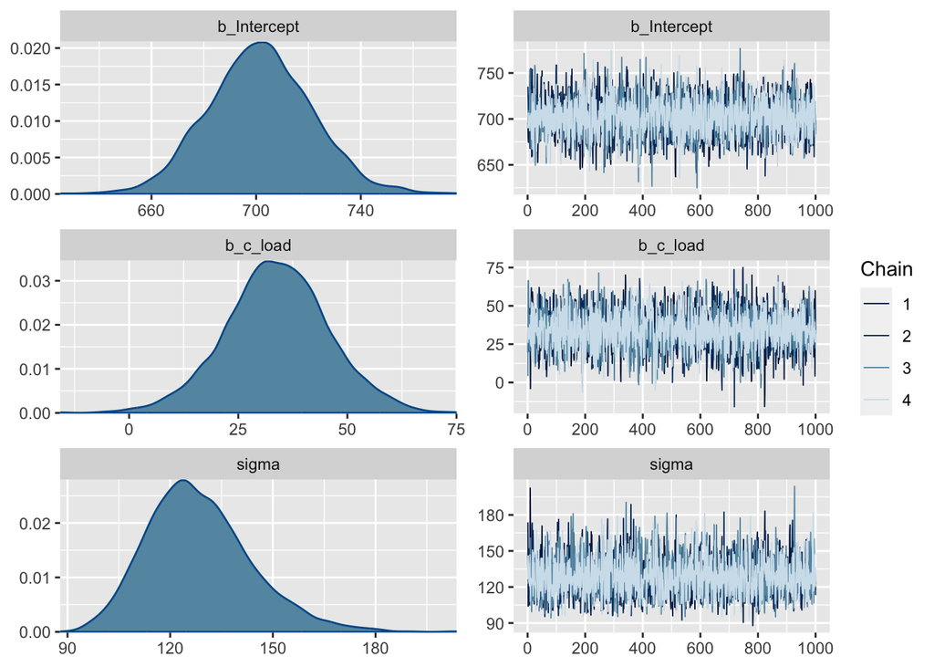

```r
plot(fit_pupil)
```

- we see:
  - intercept is around 700 (the average pupil size, because we centered the predictor)
  - c_load: range of variability in pupil size change with an increase of 1 unit of load
    - effect size is mainly between 10-60
- we see sigma is in the positive range
- we also see the chains are on top of each other (and so are sampling from the same distribution)

```r
# a function they wrote, will be shared with us
short_summary(fit_pupil)
```

[output not shown]

### 4.2.1 Posterior predictive check

- we can now get more future simulated data sets
- having fit the model, we can generate new data repeatedly using our posterior distributions of our parameters

```r
for (l in 0:4) { # for the cognitive load levels 0:4
  df_sub_pupil <- filter(df_pupil, load == l) # filter out other loads
  d <- pp_check(fit_pupil, # run pp_check
    type = "dens_overlay",
    ndraws = 100,
    newdata = df_sub_pupil # using this new data with filtering
  ) +
    # and plot it
    geom_point(data = df_sub_pupil, aes(x = p_size, y = 0.0001)) +
    ggtitle(paste("load: ", l)) +
    coord_cartesian(xlim = c(400, 1000))
  # print(d)
    # and store object as p_l
  name <- paste0("dens_",l)
  assign(name, d)
}
```

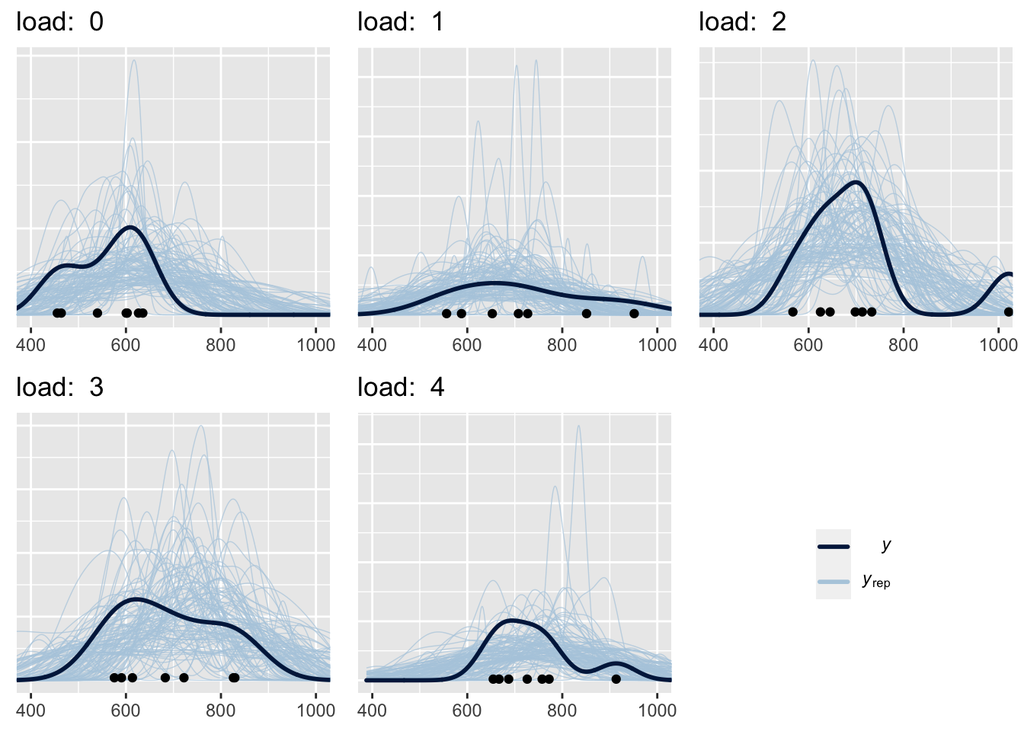

```r
ggpubr::ggarrange(
  dens_0 + theme(legend.position = "none"),
  dens_1 + theme(legend.position = "none"),
  dens_2 + theme(legend.position = "none"),
  dens_3 + theme(legend.position = "none"),
  dens_4 + theme(legend.position = "none"),
  cowplot::get_legend(dens_4),
  nrow=2, ncol = 3)
```

```r
  for (l in 0:4) {
  df_sub_pupil <- filter(df_pupil, load == l)
  p <- pp_check(fit_pupil,
    type = "stat",
    ndraws = 1000,
    newdata = df_sub_pupil,
    stat = "mean"
  ) +
    geom_point(data = df_sub_pupil, aes(x = p_size, y = 0.1)) +
    ggtitle(paste("load: ", l)) +
    coord_cartesian(xlim = c(400, 1000))
  # print(p)
  # and store object as p_l
  name <- paste0("p_",l)
  assign(name, p)
  }
```

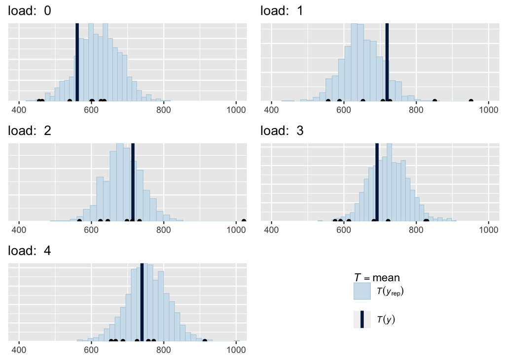

```r
ggpubr::ggarrange(
  p_0 + theme(legend.position = "none"),
  p_1 + theme(legend.position = "none"),
  p_2 + theme(legend.position = "none"),
  p_3 + theme(legend.position = "none"),
  p_4 + theme(legend.position = "none"),
  cowplot::get_legend(p_4),
  nrow=3 , ncol = 2)
```